# Risk Factor Analysis

## Outcome Variable

**Outcome Variable:** wast_rec90d

## Predictor Variables

**Intervention Variable:** hhwealth_quart

**Adjustment Set:**

- arm
- sex
- W_mage
- meducyrs
- feducyrs
- W_gagebrth
- W_birthwt
- W_birthlen
- W_nchldlt5
- W_parity
- delta_W_mage
- delta_meducyrs
- delta_feducyrs
- delta_W_gagebrth
- delta_W_birthwt
- delta_W_birthlen
- delta_W_nchldlt5
- delta_W_parity

## Stratifying Variables

The analysis was stratified on these variable(s):

- agecat
- studyid
- country

## Data Summary

| agecat | studyid | country | hhwealth_quart | wast_rec90d | n_cell | n |
| --- | --- | --- | --- | --- | --- | --- |
| 0-24 months | ki0047075b-MAL-ED | BANGLADESH | Wealth Q4 | 0 | 2 | 41 |
| 0-24 months | ki0047075b-MAL-ED | BANGLADESH | Wealth Q4 | 1 | 3 | 41 |
| 0-24 months | ki0047075b-MAL-ED | BANGLADESH | Wealth Q1 | 0 | 9 | 41 |
| 0-24 months | ki0047075b-MAL-ED | BANGLADESH | Wealth Q1 | 1 | 8 | 41 |
| 0-24 months | ki0047075b-MAL-ED | BANGLADESH | Wealth Q2 | 0 | 6 | 41 |
| 0-24 months | ki0047075b-MAL-ED | BANGLADESH | Wealth Q2 | 1 | 8 | 41 |
| 0-24 months | ki0047075b-MAL-ED | BANGLADESH | Wealth Q3 | 0 | 4 | 41 |
| 0-24 months | ki0047075b-MAL-ED | BANGLADESH | Wealth Q3 | 1 | 1 | 41 |
| 0-24 months | ki0047075b-MAL-ED | INDIA | Wealth Q4 | 0 | 6 | 65 |
| 0-24 months | ki0047075b-MAL-ED | INDIA | Wealth Q4 | 1 | 11 | 65 |
| 0-24 months | ki0047075b-MAL-ED | INDIA | Wealth Q1 | 0 | 7 | 65 |
| 0-24 months | ki0047075b-MAL-ED | INDIA | Wealth Q1 | 1 | 14 | 65 |
| 0-24 months | ki0047075b-MAL-ED | INDIA | Wealth Q2 | 0 | 3 | 65 |
| 0-24 months | ki0047075b-MAL-ED | INDIA | Wealth Q2 | 1 | 6 | 65 |
| 0-24 months | ki0047075b-MAL-ED | INDIA | Wealth Q3 | 0 | 6 | 65 |
| 0-24 months | ki0047075b-MAL-ED | INDIA | Wealth Q3 | 1 | 12 | 65 |
| 0-24 months | ki0047075b-MAL-ED | NEPAL | Wealth Q4 | 0 | 0 | 12 |
| 0-24 months | ki0047075b-MAL-ED | NEPAL | Wealth Q4 | 1 | 2 | 12 |
| 0-24 months | ki0047075b-MAL-ED | NEPAL | Wealth Q1 | 0 | 0 | 12 |
| 0-24 months | ki0047075b-MAL-ED | NEPAL | Wealth Q1 | 1 | 5 | 12 |
| 0-24 months | ki0047075b-MAL-ED | NEPAL | Wealth Q2 | 0 | 0 | 12 |
| 0-24 months | ki0047075b-MAL-ED | NEPAL | Wealth Q2 | 1 | 2 | 12 |
| 0-24 months | ki0047075b-MAL-ED | NEPAL | Wealth Q3 | 0 | 0 | 12 |
| 0-24 months | ki0047075b-MAL-ED | NEPAL | Wealth Q3 | 1 | 3 | 12 |
| 0-24 months | ki0047075b-MAL-ED | PERU | Wealth Q4 | 0 | 1 | 8 |
| 0-24 months | ki0047075b-MAL-ED | PERU | Wealth Q4 | 1 | 3 | 8 |
| 0-24 months | ki0047075b-MAL-ED | PERU | Wealth Q1 | 0 | 0 | 8 |
| 0-24 months | ki0047075b-MAL-ED | PERU | Wealth Q1 | 1 | 1 | 8 |
| 0-24 months | ki0047075b-MAL-ED | PERU | Wealth Q2 | 0 | 1 | 8 |
| 0-24 months | ki0047075b-MAL-ED | PERU | Wealth Q2 | 1 | 1 | 8 |

[output cut: 378 more lines]

The following strata were considered:

- agecat: 0-24 months, studyid: ki0047075b-MAL-ED, country: BANGLADESH
- agecat: 0-24 months, studyid: ki0047075b-MAL-ED, country: INDIA
- agecat: 0-24 months, studyid: ki0047075b-MAL-ED, country: NEPAL
- agecat: 0-24 months, studyid: ki0047075b-MAL-ED, country: PERU
- agecat: 0-24 months, studyid: ki0047075b-MAL-ED, country: SOUTH AFRICA
- agecat: 0-24 months, studyid: ki0047075b-MAL-ED, country: TANZANIA, UNITED REPUBLIC OF
- agecat: 0-24 months, studyid: ki1000108-CMC-V-BCS-2002, country: INDIA
- agecat: 0-24 months, studyid: ki1000108-IRC, country: INDIA
- agecat: 0-24 months, studyid: ki1017093b-PROVIDE, country: BANGLADESH
- agecat: 0-24 months, studyid: ki1066203-TanzaniaChild2, country: TANZANIA, UNITED REPUBLIC OF
- agecat: 0-24 months, studyid: ki1113344-GMS-Nepal, country: NEPAL
- agecat: 0-24 months, studyid: ki1114097-CONTENT, country: PERU
- agecat: 0-24 months, studyid: ki1135781-COHORTS, country: GUATEMALA
- agecat: 0-24 months, studyid: ki1135781-COHORTS, country: PHILIPPINES
- agecat: 0-24 months, studyid: ki1148112-LCNI-5, country: MALAWI
- agecat: 0-24 months, studyid: kiGH5241-JiVitA-3, country: BANGLADESH
- agecat: 0-24 months, studyid: kiGH5241-JiVitA-4, country: BANGLADESH
- agecat: 0-6 months, studyid: ki0047075b-MAL-ED, country: BANGLADESH
- agecat: 0-6 months, studyid: ki0047075b-MAL-ED, country: INDIA
- agecat: 0-6 months, studyid: ki0047075b-MAL-ED, country: NEPAL
- agecat: 0-6 months, studyid: ki0047075b-MAL-ED, country: PERU
- agecat: 0-6 months, studyid: ki0047075b-MAL-ED, country: SOUTH AFRICA
- agecat: 0-6 months, studyid: ki0047075b-MAL-ED, country: TANZANIA, UNITED REPUBLIC OF
- agecat: 0-6 months, studyid: ki1000108-CMC-V-BCS-2002, country: INDIA
- agecat: 0-6 months, studyid: ki1000108-IRC, country: INDIA
- agecat: 0-6 months, studyid: ki1017093b-PROVIDE, country: BANGLADESH
- agecat: 0-6 months, studyid: ki1066203-TanzaniaChild2, country: TANZANIA, UNITED REPUBLIC OF
- agecat: 0-6 months, studyid: ki1113344-GMS-Nepal, country: NEPAL
- agecat: 0-6 months, studyid: ki1114097-CONTENT, country: PERU
- agecat: 0-6 months, studyid: ki1135781-COHORTS, country: GUATEMALA
- agecat: 0-6 months, studyid: ki1135781-COHORTS, country: PHILIPPINES
- agecat: 0-6 months, studyid: ki1148112-LCNI-5, country: MALAWI
- agecat: 0-6 months, studyid: kiGH5241-JiVitA-3, country: BANGLADESH
- agecat: 0-6 months, studyid: kiGH5241-JiVitA-4, country: BANGLADESH
- agecat: 6-24 months, studyid: ki0047075b-MAL-ED, country: BANGLADESH
- agecat: 6-24 months, studyid: ki0047075b-MAL-ED, country: INDIA
- agecat: 6-24 months, studyid: ki0047075b-MAL-ED, country: NEPAL
- agecat: 6-24 months, studyid: ki0047075b-MAL-ED, country: PERU
- agecat: 6-24 months, studyid: ki0047075b-MAL-ED, country: SOUTH AFRICA
- agecat: 6-24 months, studyid: ki0047075b-MAL-ED, country: TANZANIA, UNITED REPUBLIC OF
- agecat: 6-24 months, studyid: ki1000108-CMC-V-BCS-2002, country: INDIA
- agecat: 6-24 months, studyid: ki1000108-IRC, country: INDIA
- agecat: 6-24 months, studyid: ki1017093b-PROVIDE, country: BANGLADESH
- agecat: 6-24 months, studyid: ki1066203-TanzaniaChild2, country: TANZANIA, UNITED REPUBLIC OF
- agecat: 6-24 months, studyid: ki1113344-GMS-Nepal, country: NEPAL
- agecat: 6-24 months, studyid: ki1114097-CONTENT, country: PERU
- agecat: 6-24 months, studyid: ki1135781-COHORTS, country: GUATEMALA
- agecat: 6-24 months, studyid: ki1135781-COHORTS, country: PHILIPPINES
- agecat: 6-24 months, studyid: ki1148112-LCNI-5, country: MALAWI
- agecat: 6-24 months, studyid: kiGH5241-JiVitA-3, country: BANGLADESH
- agecat: 6-24 months, studyid: kiGH5241-JiVitA-4, country: BANGLADESH

### Dropped Strata

Some strata were dropped due to rare outcomes:

- agecat: 0-24 months, studyid: ki0047075b-MAL-ED, country: BANGLADESH
- agecat: 0-24 months, studyid: ki0047075b-MAL-ED, country: INDIA
- agecat: 0-24 months, studyid: ki0047075b-MAL-ED, country: NEPAL
- agecat: 0-24 months, studyid: ki0047075b-MAL-ED, country: PERU
- agecat: 0-24 months, studyid: ki0047075b-MAL-ED, country: SOUTH AFRICA
- agecat: 0-24 months, studyid: ki0047075b-MAL-ED, country: TANZANIA, UNITED REPUBLIC OF
- agecat: 0-24 months, studyid: ki1114097-CONTENT, country: PERU
- agecat: 0-24 months, studyid: ki1148112-LCNI-5, country: MALAWI
- agecat: 0-6 months, studyid: ki0047075b-MAL-ED, country: BANGLADESH
- agecat: 0-6 months, studyid: ki0047075b-MAL-ED, country: INDIA
- agecat: 0-6 months, studyid: ki0047075b-MAL-ED, country: NEPAL
- agecat: 0-6 months, studyid: ki0047075b-MAL-ED, country: PERU
- agecat: 0-6 months, studyid: ki0047075b-MAL-ED, country: SOUTH AFRICA
- agecat: 0-6 months, studyid: ki0047075b-MAL-ED, country: TANZANIA, UNITED REPUBLIC OF
- agecat: 0-6 months, studyid: ki1114097-CONTENT, country: PERU
- agecat: 0-6 months, studyid: ki1148112-LCNI-5, country: MALAWI
- agecat: 6-24 months, studyid: ki0047075b-MAL-ED, country: BANGLADESH
- agecat: 6-24 months, studyid: ki0047075b-MAL-ED, country: INDIA
- agecat: 6-24 months, studyid: ki0047075b-MAL-ED, country: NEPAL
- agecat: 6-24 months, studyid: ki0047075b-MAL-ED, country: PERU
- agecat: 6-24 months, studyid: ki0047075b-MAL-ED, country: SOUTH AFRICA
- agecat: 6-24 months, studyid: ki0047075b-MAL-ED, country: TANZANIA, UNITED REPUBLIC OF
- agecat: 6-24 months, studyid: ki1017093b-PROVIDE, country: BANGLADESH
- agecat: 6-24 months, studyid: ki1114097-CONTENT, country: PERU
- agecat: 6-24 months, studyid: ki1135781-COHORTS, country: GUATEMALA
- agecat: 6-24 months, studyid: ki1148112-LCNI-5, country: MALAWI
- agecat: 6-24 months, studyid: kiGH5241-JiVitA-3, country: BANGLADESH

## Methods Detail

We’re interested in the causal parameters $E[Y_a]$ for all values of $a \in \mathcal{A}$. These parameters represent the mean outcome if, possibly contrary to fact, we intervened to set all units to have $A=a$. Under the randomization and positivity assumptions, these are identified by the statistical parameters $\psi_a=E_W[E_{Y|A,W}(Y|A=a,W)]$. In addition, we’re interested in the mean of $Y$, $E[Y]$ under no intervention (the observed mean). We will estimate these parameters by using SuperLearner to fit the relevant likelihood factors – $E_{Y|A,W}(Y|A=a,W)$ and $p(A=a|W)$, and then updating our likelihood fit using a joint TMLE.

For unadjusted analyses ($W=\{\}$), initial likelihoods were estimated using Lrnr_glm to estimate the simple $E(Y|A)$ and Lrnr_mean to estimate $p(A)$. For adjusted analyses, a small library containing Lrnr_glmnet, Lrnr_xgboost, and Lrnr_mean was used.

Having estimated these parameters, we will then use the delta method to estimate relative risks and attributable risks relative to a prespecified baseline level of $A$.

# Results Detail

## Results Plots

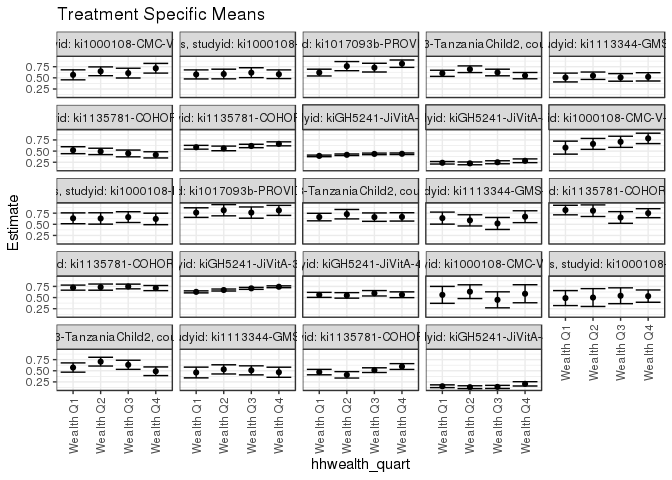

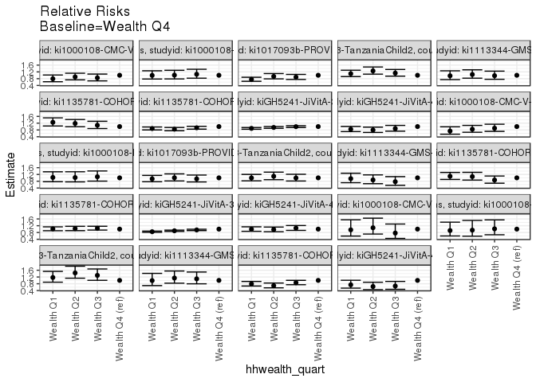

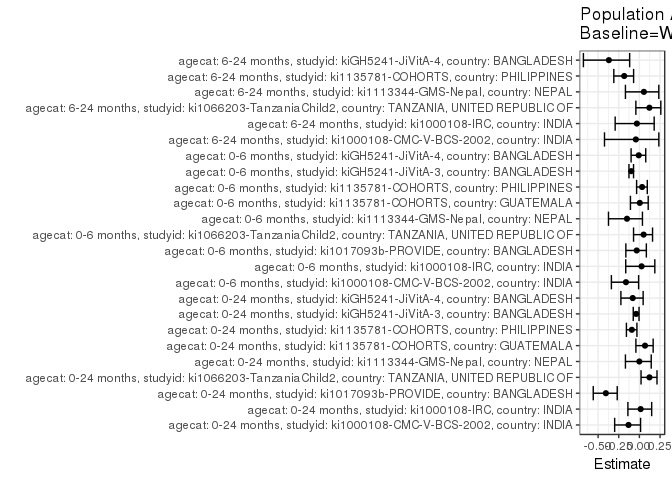

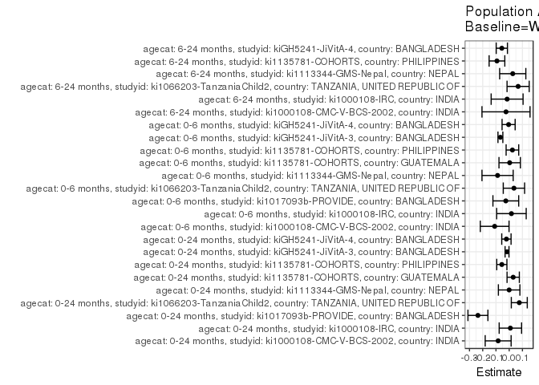

## Results Table

### Parameter: TSM

| agecat | studyid | country | intervention_level | baseline_level | estimate | ci_lower | ci_upper |
| --- | --- | --- | --- | --- | --- | --- | --- |
| 0-24 months | ki1000108-CMC-V-BCS-2002 | INDIA | Wealth Q4 | NA | 0.7152942 | 0.6062623 | 0.8243260 |
| 0-24 months | ki1000108-CMC-V-BCS-2002 | INDIA | Wealth Q1 | NA | 0.5678296 | 0.4554423 | 0.6802169 |
| 0-24 months | ki1000108-CMC-V-BCS-2002 | INDIA | Wealth Q2 | NA | 0.6469861 | 0.5486205 | 0.7453517 |
| 0-24 months | ki1000108-CMC-V-BCS-2002 | INDIA | Wealth Q3 | NA | 0.6063235 | 0.4968269 | 0.7158201 |
| 0-24 months | ki1000108-IRC | INDIA | Wealth Q4 | NA | 0.5809524 | 0.4835796 | 0.6783252 |
| 0-24 months | ki1000108-IRC | INDIA | Wealth Q1 | NA | 0.5769231 | 0.4754717 | 0.6783744 |
| 0-24 months | ki1000108-IRC | INDIA | Wealth Q2 | NA | 0.5862069 | 0.4781803 | 0.6942335 |
| 0-24 months | ki1000108-IRC | INDIA | Wealth Q3 | NA | 0.6161616 | 0.5052331 | 0.7270901 |
| 0-24 months | ki1017093b-PROVIDE | BANGLADESH | Wealth Q4 | NA | 0.8179871 | 0.7356704 | 0.9003038 |
| 0-24 months | ki1017093b-PROVIDE | BANGLADESH | Wealth Q1 | NA | 0.6184016 | 0.5426558 | 0.6941474 |
| 0-24 months | ki1017093b-PROVIDE | BANGLADESH | Wealth Q2 | NA | 0.7625949 | 0.6599696 | 0.8652201 |
| 0-24 months | ki1017093b-PROVIDE | BANGLADESH | Wealth Q3 | NA | 0.7292179 | 0.6310710 | 0.8273649 |
| 0-24 months | ki1066203-TanzaniaChild2 | TANZANIA, UNITED REPUBLIC OF | Wealth Q4 | NA | 0.5496698 | 0.4796874 | 0.6196522 |
| 0-24 months | ki1066203-TanzaniaChild2 | TANZANIA, UNITED REPUBLIC OF | Wealth Q1 | NA | 0.6016791 | 0.5324885 | 0.6708696 |
| 0-24 months | ki1066203-TanzaniaChild2 | TANZANIA, UNITED REPUBLIC OF | Wealth Q2 | NA | 0.6929742 | 0.6181157 | 0.7678327 |
| 0-24 months | ki1066203-TanzaniaChild2 | TANZANIA, UNITED REPUBLIC OF | Wealth Q3 | NA | 0.6201778 | 0.5460924 | 0.6942633 |
| 0-24 months | ki1113344-GMS-Nepal | NEPAL | Wealth Q4 | NA | 0.5227273 | 0.4294558 | 0.6159987 |
| 0-24 months | ki1113344-GMS-Nepal | NEPAL | Wealth Q1 | NA | 0.5075758 | 0.4084335 | 0.6067180 |
| 0-24 months | ki1113344-GMS-Nepal | NEPAL | Wealth Q2 | NA | 0.5472973 | 0.4645183 | 0.6300763 |
| 0-24 months | ki1113344-GMS-Nepal | NEPAL | Wealth Q3 | NA | 0.5100671 | 0.4248533 | 0.5952809 |
| 0-24 months | ki1135781-COHORTS | GUATEMALA | Wealth Q4 | NA | 0.4154234 | 0.3462038 | 0.4846431 |
| 0-24 months | ki1135781-COHORTS | GUATEMALA | Wealth Q1 | NA | 0.5198412 | 0.4420502 | 0.5976321 |
| 0-24 months | ki1135781-COHORTS | GUATEMALA | Wealth Q2 | NA | 0.4922669 | 0.4210939 | 0.5634400 |
| 0-24 months | ki1135781-COHORTS | GUATEMALA | Wealth Q3 | NA | 0.4470979 | 0.3712349 | 0.5229608 |
| 0-24 months | ki1135781-COHORTS | PHILIPPINES | Wealth Q4 | NA | 0.6625651 | 0.6179204 | 0.7072097 |
| 0-24 months | ki1135781-COHORTS | PHILIPPINES | Wealth Q1 | NA | 0.5853863 | 0.5429535 | 0.6278191 |
| 0-24 months | ki1135781-COHORTS | PHILIPPINES | Wealth Q2 | NA | 0.5600677 | 0.5080236 | 0.6121117 |
| 0-24 months | ki1135781-COHORTS | PHILIPPINES | Wealth Q3 | NA | 0.6148868 | 0.5768803 | 0.6528933 |
| 0-24 months | kiGH5241-JiVitA-3 | BANGLADESH | Wealth Q4 | NA | 0.4391817 | 0.4216065 | 0.4567569 |
| 0-24 months | kiGH5241-JiVitA-3 | BANGLADESH | Wealth Q1 | NA | 0.3921726 | 0.3748826 | 0.4094626 |

[output cut: 66 more lines]

### Parameter: E(Y)

| agecat | studyid | country | intervention_level | baseline_level | estimate | ci_lower | ci_upper |
| --- | --- | --- | --- | --- | --- | --- | --- |
| 0-24 months | ki1000108-CMC-V-BCS-2002 | INDIA | NA | NA | 0.6319018 | 0.5759256 | 0.6878781 |
| 0-24 months | ki1000108-IRC | INDIA | NA | NA | 0.5898734 | 0.5376978 | 0.6420491 |
| 0-24 months | ki1017093b-PROVIDE | BANGLADESH | NA | NA | 0.5816993 | 0.5247676 | 0.6386311 |
| 0-24 months | ki1066203-TanzaniaChild2 | TANZANIA, UNITED REPUBLIC OF | NA | NA | 0.6258790 | 0.5881498 | 0.6636083 |
| 0-24 months | ki1113344-GMS-Nepal | NEPAL | NA | NA | 0.5222816 | 0.4773852 | 0.5671781 |
| 0-24 months | ki1135781-COHORTS | GUATEMALA | NA | NA | 0.4456522 | 0.3930622 | 0.4982422 |
| 0-24 months | ki1135781-COHORTS | PHILIPPINES | NA | NA | 0.6068680 | 0.5823645 | 0.6313715 |
| 0-24 months | kiGH5241-JiVitA-3 | BANGLADESH | NA | NA | 0.4227159 | 0.4115895 | 0.4338422 |
| 0-24 months | kiGH5241-JiVitA-4 | BANGLADESH | NA | NA | 0.2613103 | 0.2419607 | 0.2806599 |
| 0-6 months | ki1000108-CMC-V-BCS-2002 | INDIA | NA | NA | 0.6748768 | 0.6092233 | 0.7405304 |
| 0-6 months | ki1000108-IRC | INDIA | NA | NA | 0.6375000 | 0.5751450 | 0.6998550 |
| 0-6 months | ki1017093b-PROVIDE | BANGLADESH | NA | NA | 0.7868852 | 0.7281477 | 0.8456228 |
| 0-6 months | ki1066203-TanzaniaChild2 | TANZANIA, UNITED REPUBLIC OF | NA | NA | 0.7020649 | 0.6526590 | 0.7514708 |
| 0-6 months | ki1113344-GMS-Nepal | NEPAL | NA | NA | 0.5833333 | 0.5108676 | 0.6557991 |
| 0-6 months | ki1135781-COHORTS | GUATEMALA | NA | NA | 0.7536232 | 0.6949302 | 0.8123162 |
| 0-6 months | ki1135781-COHORTS | PHILIPPINES | NA | NA | 0.7367021 | 0.7051294 | 0.7682749 |
| 0-6 months | kiGH5241-JiVitA-3 | BANGLADESH | NA | NA | 0.6753274 | 0.6619885 | 0.6886664 |
| 0-6 months | kiGH5241-JiVitA-4 | BANGLADESH | NA | NA | 0.5583942 | 0.5167799 | 0.6000084 |
| 6-24 months | ki1000108-CMC-V-BCS-2002 | INDIA | NA | NA | 0.5609756 | 0.4682842 | 0.6536670 |
| 6-24 months | ki1000108-IRC | INDIA | NA | NA | 0.5161290 | 0.4322562 | 0.6000019 |
| 6-24 months | ki1066203-TanzaniaChild2 | TANZANIA, UNITED REPUBLIC OF | NA | NA | 0.5564516 | 0.5041613 | 0.6087419 |
| 6-24 months | ki1113344-GMS-Nepal | NEPAL | NA | NA | 0.4934383 | 0.4388573 | 0.5480193 |
| 6-24 months | ki1135781-COHORTS | PHILIPPINES | NA | NA | 0.5026681 | 0.4688378 | 0.5364984 |
| 6-24 months | kiGH5241-JiVitA-4 | BANGLADESH | NA | NA | 0.1508986 | 0.1332882 | 0.1685090 |

### Parameter: RR

| agecat | studyid | country | intervention_level | baseline_level | estimate | ci_lower | ci_upper |
| --- | --- | --- | --- | --- | --- | --- | --- |
| 0-24 months | ki1000108-CMC-V-BCS-2002 | INDIA | Wealth Q4 | Wealth Q4 | 1.0000000 | 1.0000000 | 1.0000000 |
| 0-24 months | ki1000108-CMC-V-BCS-2002 | INDIA | Wealth Q1 | Wealth Q4 | 0.7938407 | 0.6190937 | 1.0179121 |
| 0-24 months | ki1000108-CMC-V-BCS-2002 | INDIA | Wealth Q2 | Wealth Q4 | 0.9045035 | 0.7303996 | 1.1201084 |
| 0-24 months | ki1000108-CMC-V-BCS-2002 | INDIA | Wealth Q3 | Wealth Q4 | 0.8476561 | 0.6702975 | 1.0719433 |
| 0-24 months | ki1000108-IRC | INDIA | Wealth Q4 | Wealth Q4 | 1.0000000 | 1.0000000 | 1.0000000 |
| 0-24 months | ki1000108-IRC | INDIA | Wealth Q1 | Wealth Q4 | 0.9930643 | 0.7789031 | 1.2661096 |
| 0-24 months | ki1000108-IRC | INDIA | Wealth Q2 | Wealth Q4 | 1.0090447 | 0.7865678 | 1.2944479 |
| 0-24 months | ki1000108-IRC | INDIA | Wealth Q3 | Wealth Q4 | 1.0606061 | 0.8293241 | 1.3563880 |
| 0-24 months | ki1017093b-PROVIDE | BANGLADESH | Wealth Q4 | Wealth Q4 | 1.0000000 | 1.0000000 | 1.0000000 |
| 0-24 months | ki1017093b-PROVIDE | BANGLADESH | Wealth Q1 | Wealth Q4 | 0.7560041 | 0.6465750 | 0.8839535 |
| 0-24 months | ki1017093b-PROVIDE | BANGLADESH | Wealth Q2 | Wealth Q4 | 0.9322823 | 0.7892254 | 1.1012699 |
| 0-24 months | ki1017093b-PROVIDE | BANGLADESH | Wealth Q3 | Wealth Q4 | 0.8914785 | 0.7552644 | 1.0522592 |
| 0-24 months | ki1066203-TanzaniaChild2 | TANZANIA, UNITED REPUBLIC OF | Wealth Q4 | Wealth Q4 | 1.0000000 | 1.0000000 | 1.0000000 |
| 0-24 months | ki1066203-TanzaniaChild2 | TANZANIA, UNITED REPUBLIC OF | Wealth Q1 | Wealth Q4 | 1.0946191 | 0.9222084 | 1.2992628 |
| 0-24 months | ki1066203-TanzaniaChild2 | TANZANIA, UNITED REPUBLIC OF | Wealth Q2 | Wealth Q4 | 1.2607100 | 1.0669582 | 1.4896457 |
| 0-24 months | ki1066203-TanzaniaChild2 | TANZANIA, UNITED REPUBLIC OF | Wealth Q3 | Wealth Q4 | 1.1282735 | 0.9478161 | 1.3430886 |
| 0-24 months | ki1113344-GMS-Nepal | NEPAL | Wealth Q4 | Wealth Q4 | 1.0000000 | 1.0000000 | 1.0000000 |
| 0-24 months | ki1113344-GMS-Nepal | NEPAL | Wealth Q1 | Wealth Q4 | 0.9710145 | 0.7454136 | 1.2648940 |
| 0-24 months | ki1113344-GMS-Nepal | NEPAL | Wealth Q2 | Wealth Q4 | 1.0470035 | 0.8288937 | 1.3225053 |
| 0-24 months | ki1113344-GMS-Nepal | NEPAL | Wealth Q3 | Wealth Q4 | 0.9757806 | 0.7643352 | 1.2457200 |
| 0-24 months | ki1135781-COHORTS | GUATEMALA | Wealth Q4 | Wealth Q4 | 1.0000000 | 1.0000000 | 1.0000000 |
| 0-24 months | ki1135781-COHORTS | GUATEMALA | Wealth Q1 | Wealth Q4 | 1.2513526 | 1.0352270 | 1.5125990 |
| 0-24 months | ki1135781-COHORTS | GUATEMALA | Wealth Q2 | Wealth Q4 | 1.1849764 | 0.9906095 | 1.4174800 |
| 0-24 months | ki1135781-COHORTS | GUATEMALA | Wealth Q3 | Wealth Q4 | 1.0762461 | 0.8832494 | 1.3114141 |
| 0-24 months | ki1135781-COHORTS | PHILIPPINES | Wealth Q4 | Wealth Q4 | 1.0000000 | 1.0000000 | 1.0000000 |
| 0-24 months | ki1135781-COHORTS | PHILIPPINES | Wealth Q1 | Wealth Q4 | 0.8835152 | 0.8014149 | 0.9740262 |
| 0-24 months | ki1135781-COHORTS | PHILIPPINES | Wealth Q2 | Wealth Q4 | 0.8453021 | 0.7546384 | 0.9468584 |
| 0-24 months | ki1135781-COHORTS | PHILIPPINES | Wealth Q3 | Wealth Q4 | 0.9280399 | 0.8482743 | 1.0153060 |
| 0-24 months | kiGH5241-JiVitA-3 | BANGLADESH | Wealth Q4 | Wealth Q4 | 1.0000000 | 1.0000000 | 1.0000000 |
| 0-24 months | kiGH5241-JiVitA-3 | BANGLADESH | Wealth Q1 | Wealth Q4 | 0.8929622 | 0.8441000 | 0.9446527 |

[output cut: 66 more lines]

### Parameter: PAR

| agecat | studyid | country | intervention_level | baseline_level | estimate | ci_lower | ci_upper |
| --- | --- | --- | --- | --- | --- | --- | --- |
| 0-24 months | ki1000108-CMC-V-BCS-2002 | INDIA | Wealth Q4 | NA | -0.0833923 | -0.1813563 | 0.0145717 |
| 0-24 months | ki1000108-IRC | INDIA | Wealth Q4 | NA | 0.0089210 | -0.0756958 | 0.0935379 |
| 0-24 months | ki1017093b-PROVIDE | BANGLADESH | Wealth Q4 | NA | -0.2362877 | -0.3117164 | -0.1608591 |
| 0-24 months | ki1066203-TanzaniaChild2 | TANZANIA, UNITED REPUBLIC OF | Wealth Q4 | NA | 0.0762092 | 0.0159344 | 0.1364841 |
| 0-24 months | ki1113344-GMS-Nepal | NEPAL | Wealth Q4 | NA | -0.0004456 | -0.0816700 | 0.0807788 |
| 0-24 months | ki1135781-COHORTS | GUATEMALA | Wealth Q4 | NA | 0.0302288 | -0.0161875 | 0.0766450 |
| 0-24 months | ki1135781-COHORTS | PHILIPPINES | Wealth Q4 | NA | -0.0556971 | -0.0941124 | -0.0172818 |
| 0-24 months | kiGH5241-JiVitA-3 | BANGLADESH | Wealth Q4 | NA | -0.0164658 | -0.0312153 | -0.0017163 |
| 0-24 months | kiGH5241-JiVitA-4 | BANGLADESH | Wealth Q4 | NA | -0.0211648 | -0.0563962 | 0.0140665 |
| 0-6 months | ki1000108-CMC-V-BCS-2002 | INDIA | Wealth Q4 | NA | -0.1097976 | -0.2182769 | -0.0013183 |
| 0-6 months | ki1000108-IRC | INDIA | Wealth Q4 | NA | 0.0168103 | -0.0947957 | 0.1284164 |
| 0-6 months | ki1017093b-PROVIDE | BANGLADESH | Wealth Q4 | NA | -0.0256148 | -0.1229526 | 0.0717230 |
| 0-6 months | ki1066203-TanzaniaChild2 | TANZANIA, UNITED REPUBLIC OF | Wealth Q4 | NA | 0.0358388 | -0.0447294 | 0.1164070 |
| 0-6 months | ki1113344-GMS-Nepal | NEPAL | Wealth Q4 | NA | -0.0877976 | -0.2056606 | 0.0300653 |
| 0-6 months | ki1135781-COHORTS | GUATEMALA | Wealth Q4 | NA | 0.0036232 | -0.0772108 | 0.0844571 |
| 0-6 months | ki1135781-COHORTS | PHILIPPINES | Wealth Q4 | NA | 0.0242949 | -0.0232594 | 0.0718492 |
| 0-6 months | kiGH5241-JiVitA-3 | BANGLADESH | Wealth Q4 | NA | -0.0664425 | -0.0848707 | -0.0480142 |
| 0-6 months | kiGH5241-JiVitA-4 | BANGLADESH | Wealth Q4 | NA | -0.0045117 | -0.0539346 | 0.0449112 |
| 6-24 months | ki1000108-CMC-V-BCS-2002 | INDIA | Wealth Q4 | NA | -0.0241229 | -0.2056533 | 0.1574075 |
| 6-24 months | ki1000108-IRC | INDIA | Wealth Q4 | NA | -0.0157859 | -0.1363138 | 0.1047420 |
| 6-24 months | ki1066203-TanzaniaChild2 | TANZANIA, UNITED REPUBLIC OF | Wealth Q4 | NA | 0.0673944 | -0.0162308 | 0.1510196 |
| 6-24 months | ki1113344-GMS-Nepal | NEPAL | Wealth Q4 | NA | 0.0267717 | -0.0721039 | 0.1256472 |
| 6-24 months | ki1135781-COHORTS | PHILIPPINES | Wealth Q4 | NA | -0.0924713 | -0.1516841 | -0.0332585 |
| 6-24 months | kiGH5241-JiVitA-4 | BANGLADESH | Wealth Q4 | NA | -0.0557817 | -0.0982342 | -0.0133291 |

### Parameter: PAF

| agecat | studyid | country | intervention_level | baseline_level | estimate | ci_lower | ci_upper |
| --- | --- | --- | --- | --- | --- | --- | --- |
| 0-24 months | ki1000108-CMC-V-BCS-2002 | INDIA | Wealth Q4 | NA | -0.1319704 | -0.2996482 | 0.0140740 |
| 0-24 months | ki1000108-IRC | INDIA | Wealth Q4 | NA | 0.0151236 | -0.1392355 | 0.1485681 |
| 0-24 months | ki1017093b-PROVIDE | BANGLADESH | Wealth Q4 | NA | -0.4062025 | -0.5587747 | -0.2685641 |
| 0-24 months | ki1066203-TanzaniaChild2 | TANZANIA, UNITED REPUBLIC OF | Wealth Q4 | NA | 0.1217635 | 0.0199548 | 0.2129962 |
| 0-24 months | ki1113344-GMS-Nepal | NEPAL | Wealth Q4 | NA | -0.0008532 | -0.1691043 | 0.1431840 |
| 0-24 months | ki1135781-COHORTS | GUATEMALA | Wealth Q4 | NA | 0.0678304 | -0.0424725 | 0.1664622 |
| 0-24 months | ki1135781-COHORTS | PHILIPPINES | Wealth Q4 | NA | -0.0917779 | -0.1572375 | -0.0300211 |
| 0-24 months | kiGH5241-JiVitA-3 | BANGLADESH | Wealth Q4 | NA | -0.0389525 | -0.0745575 | -0.0045273 |
| 0-24 months | kiGH5241-JiVitA-4 | BANGLADESH | Wealth Q4 | NA | -0.0809950 | -0.2239785 | 0.0452854 |
| 0-6 months | ki1000108-CMC-V-BCS-2002 | INDIA | Wealth Q4 | NA | -0.1626928 | -0.3390895 | -0.0095326 |
| 0-6 months | ki1000108-IRC | INDIA | Wealth Q4 | NA | 0.0263692 | -0.1655019 | 0.1866534 |
| 0-6 months | ki1017093b-PROVIDE | BANGLADESH | Wealth Q4 | NA | -0.0325521 | -0.1640542 | 0.0840943 |
| 0-6 months | ki1066203-TanzaniaChild2 | TANZANIA, UNITED REPUBLIC OF | Wealth Q4 | NA | 0.0510477 | -0.0709039 | 0.1591118 |
| 0-6 months | ki1113344-GMS-Nepal | NEPAL | Wealth Q4 | NA | -0.1505102 | -0.3742466 | 0.0368004 |
| 0-6 months | ki1135781-COHORTS | GUATEMALA | Wealth Q4 | NA | 0.0048077 | -0.1084546 | 0.1064968 |
| 0-6 months | ki1135781-COHORTS | PHILIPPINES | Wealth Q4 | NA | 0.0329779 | -0.0338257 | 0.0954649 |
| 0-6 months | kiGH5241-JiVitA-3 | BANGLADESH | Wealth Q4 | NA | -0.0983856 | -0.1264790 | -0.0709928 |
| 0-6 months | kiGH5241-JiVitA-4 | BANGLADESH | Wealth Q4 | NA | -0.0080798 | -0.1005907 | 0.0766551 |
| 6-24 months | ki1000108-CMC-V-BCS-2002 | INDIA | Wealth Q4 | NA | -0.0430017 | -0.4226774 | 0.2353484 |
| 6-24 months | ki1000108-IRC | INDIA | Wealth Q4 | NA | -0.0305851 | -0.2935436 | 0.1789178 |
| 6-24 months | ki1066203-TanzaniaChild2 | TANZANIA, UNITED REPUBLIC OF | Wealth Q4 | NA | 0.1211145 | -0.0428534 | 0.2593018 |
| 6-24 months | ki1113344-GMS-Nepal | NEPAL | Wealth Q4 | NA | 0.0542553 | -0.1691361 | 0.2349625 |
| 6-24 months | ki1135781-COHORTS | PHILIPPINES | Wealth Q4 | NA | -0.1839610 | -0.3098169 | -0.0701982 |
| 6-24 months | kiGH5241-JiVitA-4 | BANGLADESH | Wealth Q4 | NA | -0.3696631 | -0.6779047 | -0.1180475 |